# Damselflies

Chandrashekar CR

01-01-2025

# Read the data

The data originates from a field monitoring project conducted in Sweden, focusing on two species of damselflies, Calopteryx splendens and Calopteryx virgo. These damselflies are commonly found in riverine aquatic habitats across Europe. Over five consecutive summers (June and July, 2011–2015), a team of researchers and students conducted repeated visits to study a single population. The dataset includes several morphological traits (linear measurements of the body, abdomen, thorax, and wings), a trait linked to sexual selection (forewing patch length and width, measured only in C. splendens), and two fitness-related variables (copulation status as a proxy for mating success, and lifespan as a proxy for longevity).

To begin, I plan to familiarize myself with damselflies and explore intriguing questions about their biology and ecology. My initial step will be a preliminary examination of the dataset to understand its structure and variables. This will allow me to formulate specific research questions that can be addressed using the collected data.

Variables included in this dataset are as follows:

- year : sampled year (unit: year)
- id : id that is unique to each individual
- sp : species identity. CS stands for C. splendens, CV stands for C. virgo
- sex : sex of the specimens. Male for male and Female for female.
- tbl : total body length, which is the distance from the front tip of the head to the
- rear tip of the abdomen (unit: mm)
- abl : abdomen length (unit: mm)
- thorl : thorax length (unit: mm)
- thorw : thorax width (unit: mm)
- fwl : forewing length (unit: mm)
- hwl : hindwing length (unit: mm)
- fpl : forewing patch length (unit: mm). Only in male C. splendens
- fpw : forewing patch width (unit: mm). Only in male C. splendens
- cop : copulation status. 0 means that the individual was always found without a partner, 1 means that the individual was found while mating with a partner at least once
- marked : date the individual was marked
- lifespan : days from date marked to date last seen (unit: days)

```r
# Clear any pre-stored variables in the environment
rm(list = ls())

# Import Libraries
library(MASS)
library(tidyverse)
```

```r
library(ggplot2)
library(patchwork)
library(dplyr)
library(MuMIn)

# Load the data
male_CS = read.csv("../data/male_CS.csv")
male_CV = read.csv("../data/male_CV.csv")
female_CS = read.csv("../data/female_CS.csv")
female_CV = read.csv("../data/female_CV.csv")

data = bind_rows(male_CS, male_CV, female_CS, female_CV)

head(data)
```

```
##   year sp        id  sex   marked lifespan cop   tbl   abl thorl thorw   fwl
## 1 2011 CS  6_7_csm2 Male 2011-6-7        0   1 46.59 36.89  4.01  4.20 31.20
## 2 2011 CS      cdbf Male 2011-6-7        0   0 45.76 35.10  3.42  4.01 30.66
## 3 2011 CS 7_1_csm28 Male 2011-7-1        9   0 46.75 36.57  3.94  3.92 28.94
## 4 2011 CS 6_7_csm13 Male 2011-6-7        5   1 46.13 35.84  3.56  4.20 30.58
## 5 2011 CS       cpp Male 2011-6-7        9   0 47.61 37.61  3.99  4.24 31.05
## 6 2011 CS       cpw Male 2011-6-7        1   0 45.79 35.39  3.81  3.84 29.32
##     hwl   fpl  fpw
## 1 29.76 16.88 9.76
## 2 29.42 16.85 9.61
## 3 27.63 14.59 9.38
## 4 29.11 16.21 9.81
## 5 30.24 16.52 9.79
## 6 28.00 15.40 9.10
```

Following a thorough literature survey, I identified several relevant papers examining variations in wing pigmentation, wing traits, and other morphological traits. I intend to conduct a comparative analysis to determine if both morphological and sexual traits contribute to copulation status. This research builds upon the findings of Golab and Brodin’s study “Looks or personality: what drives damselfly male mating success in the wild?” (2023), which will serve as a theoretical framework to compare whether my results align with their findings.

The research question will be addressed through a sequential analysis of four sub-questions:

- What is the relationship between copulation status and individual sexual traits (forewing patch length and width)? This will be analyzed using analysis of variance (ANOVA).
- Which predictor better explains copulation status: forewing patch length alone, width alone, or both measures combined? This relationship will be examined using logistic regression models.
- How do morphological traits collectively influence copulation status? A comprehensive logistic regression analysis will be conducted using all available morphological traits as predictors.
- Which better predicts copulation status: morphological traits, sexual traits, or a combination of both? A comparative analysis of logistic regression models will be used to evaluate the relative importance of these trait categories.

This systematic approach will allow us to understand both the individual and combined effects of morphological and sexual traits on mating success.

# Statistical Analysis Plan for Copulation Status Study

## Analysis 1: Sexual Traits and Copulation Status

```r
# Load necessary libraries
library(ggplot2)
library(dplyr)

# Clear the environment
rm(list = ls())

# Read and prepare the data
male_CS = read.csv("../data/male_CS.csv")
male_CS = male_CS %>%
  select(fpl, fpw, cop) %>%
  mutate(cop = as.factor(cop))

# Verify normality within copulation status groups

# 1. ---------- Forewing Patch Width (FPW) ---------------

# Histogram
fpw_histogram = male_CS %>%
  ggplot(aes(x = fpw, fill = cop)) +
  geom_histogram(alpha = 0.6, bins = 15, position = "identity") +
  facet_wrap(~cop) +
  theme_classic() +
  labs(
    title = "Distribution of FPW by Copulation Status",
    x = "Forewing Patch Width (mm)",
    y = "Frequency"
  ) +
  theme(
    axis.text = element_text(size = 12),
    axis.title = element_text(size = 14),
    plot.title = element_text(size = 16, hjust = 0.5)
  )

# Save histogram
ggsave(
  "../results/fpw_histogram.png",
  fpw_histogram,
  width = 200,
  height = 100,
  units = "mm",
  dpi = 600
)

# Q-Q Plot
fpw_qq = male_CS %>%
  ggplot(aes(sample = fpw, color = cop)) +
  stat_qq() +
  stat_qq_line() +
  facet_wrap(~cop) +
  theme_classic() +
  labs(
    title = "Q-Q Plot for FPW by Copulation Status",
    x = "Theoretical Quantiles",
    y = "Sample Quantiles"
  ) +
  theme(
    axis.text = element_text(size = 12),
    axis.title = element_text(size = 14),
    plot.title = element_text(size = 16, hjust = 0.5),
    legend.position = "none"
  )

# Save Q-Q plot
ggsave(
  "../results/fpw_qq.png",
  fpw_qq,
  width = 200,
  height = 100,
  units = "mm",
  dpi = 600
)

# 2. ---------- Forewing Patch Length (FPL) ---------------

# Histogram
fpl_histogram = male_CS %>%
  ggplot(aes(x = fpl, fill = cop)) +
  geom_histogram(alpha = 0.6, bins = 15, position = "identity") +
  facet_wrap(~cop) +
  theme_classic() +
  labs(
    title = "Distribution of FPL by Copulation Status",
    x = "Forewing Patch Length (mm)",
    y = "Frequency"
  ) +
  theme(
    axis.text = element_text(size = 12),
    axis.title = element_text(size = 14),
    plot.title = element_text(size = 16, hjust = 0.5)
  )

# Save histogram
ggsave(
  "../results/fpl_histogram.png",
  fpl_histogram,
  width = 200,
  height = 100,
  units = "mm",
  dpi = 600
)

# Q-Q Plot
fpl_qq = male_CS %>%
  ggplot(aes(sample = fpl, color = cop)) +
  stat_qq() +
  stat_qq_line() +
  facet_wrap(~cop) +
  theme_classic() +
  labs(
    title = "Q-Q Plot for FPL by Copulation Status",
    x = "Theoretical Quantiles",
    y = "Sample Quantiles"
  ) +
  theme(
    axis.text = element_text(size = 12),
    axis.title = element_text(size = 14),
    plot.title = element_text(size = 16, hjust = 0.5),
    legend.position = "none"
  )

# Save Q-Q plot
ggsave(
  "../results/fpl_qq.png",
  fpl_qq,
  width = 200,
  height = 100,
  units = "mm",
  dpi = 600
)

# Perform ANOVA for FPL
anova_fpl = lm(fpl ~ as.factor(cop), data = male_CS)
anova_result_fpl = anova(anova_fpl)
summary_fpl = summary(anova_fpl)

# Perform ANOVA for FPW
anova_fpw = lm(fpw ~ as.factor(cop), data = male_CS)
anova_result_fpw = anova(anova_fpw)
summary_fpw = summary(anova_fpw)

# Print ANOVA results
print(anova_result_fpl)
```

```
## Analysis of Variance Table
##
## Response: fpl
##                  Df Sum Sq Mean Sq F value Pr(>F)
## as.factor(cop)    1    0.9 0.92391  0.3164 0.5739
## Residuals      2033 5937.2 2.92043
```

```r
print(summary_fpl)
```

```
##
## Call:
## lm(formula = fpl ~ as.factor(cop), data = male_CS)
##
## Residuals:
##     Min      1Q  Median      3Q     Max
## -5.2753 -1.1852 -0.1261  1.0831 12.5919
##
## Coefficients:
##                 Estimate Std. Error t value Pr(>|t|)
## (Intercept)     16.65805    0.04110 405.320   <2e-16 ***
## as.factor(cop)1  0.05961    0.10599   0.562    0.574
## ---
## Signif. codes:  0 '***' 0.001 '**' 0.01 '*' 0.05 '.' 0.1 ' ' 1
##
## Residual standard error: 1.709 on 2033 degrees of freedom
## Multiple R-squared:  0.0001556,  Adjusted R-squared:  -0.0003362
## F-statistic: 0.3164 on 1 and 2033 DF,  p-value: 0.5739
```

```r
print(anova_result_fpw)
```

```
## Analysis of Variance Table
##
## Response: fpw
##                  Df Sum Sq Mean Sq F value   Pr(>F)
## as.factor(cop)    1   3.76  3.7551  22.688 2.04e-06 ***
## Residuals      2033 336.49  0.1655
## ---
## Signif. codes:  0 '***' 0.001 '**' 0.01 '*' 0.05 '.' 0.1 ' ' 1
```

```r
print(summary_fpw)
```

```
##
## Call:
## lm(formula = fpw ~ as.factor(cop), data = male_CS)
##
## Residuals:
##      Min       1Q   Median       3Q      Max
## -3.07243 -0.22927  0.02134  0.26610  2.52240
##
## Coefficients:
##                  Estimate Std. Error t value Pr(>|t|)
## (Intercept)      9.584960   0.009784 979.649  < 2e-16 ***
## as.factor(cop)1 -0.120181   0.025231  -4.763 2.04e-06 ***
## ---
## Signif. codes:  0 '***' 0.001 '**' 0.01 '*' 0.05 '.' 0.1 ' ' 1
##
## Residual standard error: 0.4068 on 2033 degrees of freedom
## Multiple R-squared:  0.01104,    Adjusted R-squared:  0.01055
## F-statistic: 22.69 on 1 and 2033 DF,  p-value: 2.04e-06
```

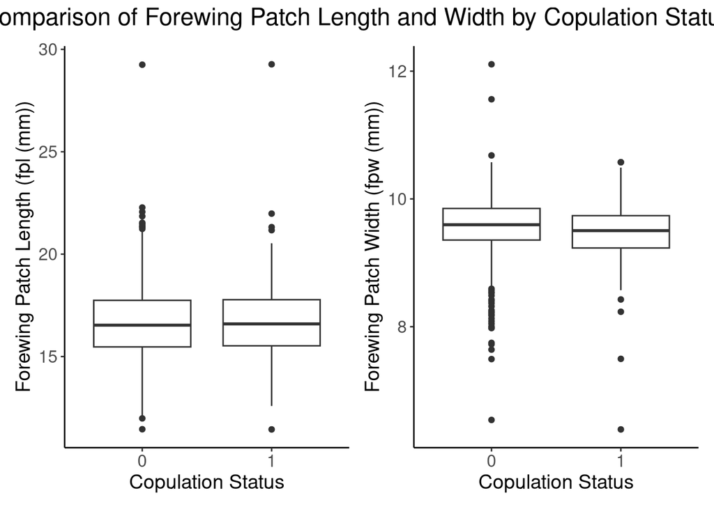

```r
# Load necessary libraries
library(ggplot2)
library(dplyr)
library(patchwork)

# Read and prepare data
male_CS = read.csv("../data/male_CS.csv")
male_CS = male_CS %>%
  select(fpl, fpw, cop) %>%
  mutate(cop = as.factor(cop))

# Boxplot for FPL
box_fpl = ggplot(male_CS, aes(x = as.factor(cop), y = fpl)) +
  geom_boxplot() +
  labs(x = "Copulation Status", y = "Forewing Patch Length (fpl (mm))") +
  theme_classic() +
  theme(
    axis.text.x = element_text(size = 12),  # Adjusted size of x-axis tick labels
    axis.text.y = element_text(size = 12),  # Adjusted size of y-axis tick labels
    axis.title = element_text(size = 14),   # Adjusted axis titles
    plot.title = element_text(size = 16, hjust = 0.5)  # Adjusted plot title
  )

# Boxplot for FPW
box_fpw = ggplot(male_CS, aes(x = as.factor(cop), y = fpw)) +
  geom_boxplot() +
  labs(x = "Copulation Status", y = "Forewing Patch Width (fpw (mm))") +
  theme_classic() +
  theme(
    axis.text.x = element_text(size = 12),  # Adjusted size of x-axis tick labels
    axis.text.y = element_text(size = 12),  # Adjusted size of y-axis tick labels
    axis.title = element_text(size = 14),   # Adjusted axis titles
    plot.title = element_text(size = 16, hjust = 0.5)  # Adjusted plot title
  )

# Combine plots side by side using patchwork
combined_plots = box_fpl + box_fpw + plot_layout(ncol = 2) +
  plot_annotation(
    title = "Comparison of Forewing Patch Length and Width by Copulation Status",
    theme = theme(plot.title = element_text(size = 17, hjust = 0.5))  # Adjusted annotation title
  )

# Display combined plots
combined_plots
```

```r
# Save the plot as a high-resolution PNG for LaTeX document
ggsave(
  "../results/anova_combined_plot.png",
  combined_plots,
  width = 200,  # Width in mm
  #height = 80,  # Adjusted height to maintain aspect ratio
  units = "mm",
  dpi = 600
)
```

```
## Saving 200 x 127 mm image
```

## Results of Sexual Traits and Copulation Status

**Response Variables and Predictor Variables:**

- Response Variables:
  - FPL (Forewing Patch Length): Continuous variable (unit: mm)
  - FPW (Forewing Patch Width): Continuous varibale (unit: mm)
- Predictor Variable:
  - Copulation Status (cop): Categorical variables with two levels:
    - 0: Individual was always found without a partner.
    - 1: Individual was found mating with partner at least once.

#### Copulation Status ~ FPL

**Variance Explained by the Model**

From the ANOVA table:

- Sum of Squares (SS):
  - Copulation Status: 0.924.
  - Residual: 5937.2.

Total SS = 0.924+5937.2=5938.124.

$R^2 = \frac{\text{SS(Copulation Status)}}{\text{Total SS}} = \frac{0.924}{5938.124} \approx 0.00016$. This is consistent with the $R^2 = 0.0001556$ from the model summary.

Parameter Estimate and Percentage Difference:

**Percentage Difference Based on Group Means**

$\text{Percentage Difference} = \frac{mean_{cop=1}-mean_{cop=0}}{mean_{cop=0}}\times100 = \frac{16.718-16.658}{16.658}\times100 \approx 0.36 \%$

**F-Statistic and P-values**

F-statistic: 0.316 p-value: 0.5739

This indicates no significant difference in FPL across copulation statuses.

#### Copulation Status ~ FPW

**Variance Explained by the Model**

From the ANOVA table:

- Sum of Squares (SS):
  - Copulation Status: 3.76.
  - Residual: 336.49

Total SS = 3.76+336.49=340.25.

$R^2 = \frac{\text{SS(Copulation Status)}}{\text{Total SS}} = \frac{3.76}{340.25} \approx 0.01104$. This is consistent with the $R^2 = 0.01104$ from the model summary.

Parameter Estimate and Percentage Difference:

**Percentage Difference Based on Group Means**

$\text{Percentage Difference} = \frac{mean_{cop=1}-mean_{cop=0}}{mean_{cop=0}}\times100 = \frac{9.465-9.585}{9.585}\times100 \approx -1.25 \%$

**F-Statistic and P-values**

F-statistic: 22.69 p-value: $2.04 \times 10^{-6}$

This indicates a significant difference in FPW across copulation statuses.

**Summary and Interpretation**:

- For FPL, the variance explained by the model ($R^2 = 0.00016$) is negligible, with no significant difference between groups ($p=0.5739$).
- For FPW, the model explains 1.1% of the variance ($R^2 = 0.01104$), and the difference between groups is statistically significant ($p = 2.04 \times 10^{-6}$).
- Individuals found mating (cop=1) have slightly smaller FPW, with a 1.25% reduction compared to individuals always found without a partner (cop=0).

## Analysis 2: Sexual Trait Assessments

- **Model Suite**:
  1. Single-predictor model: Copulation status ~ FPL
  2. Single-predictor model: Copulation status ~ FPW
  3. Combined model: Copulation status ~ FPL + FPW
  4. Interaction model: Copulation status ~ FPL + FPW + (FPL × FPW)

```r
# Clear the environment
rm(list = ls())

# Read the data and filter accordingly
male_CS = read.csv("../data/male_CS.csv")

# Selects only the columns fpl, fpw, and cop from the dataset.
# Converts the `cop` variable (copulation status) into a categorical variable (factor).
male_CS = male_CS %>%
  select(fpl, fpw, cop) %>%
  mutate(cop = as.factor(cop))


# Logistic regression model: Copulation status as a function of forewing patch length (fpl)
logit_model_fpl = glm(cop ~ fpl, data = male_CS, family = binomial(link = "logit"))
#summary(logit_model_fpl)


# Logistic regression model: Copulation status as a function of forewing patch width (fpw)
logit_model_fpw = glm(cop ~ fpw, data = male_CS, family = binomial(link = "logit"))
#summary(logit_model_fpw)

# Logistic regression model: Copulation status as a function of both fpl and fpw
logit_model_fpl_fpw = glm(cop ~ fpw + fpl, data = male_CS, family = binomial(link = "logit"))
summary(logit_model_fpl_fpw)
```

```
##
## Call:
## glm(formula = cop ~ fpw + fpl, family = binomial(link = "logit"),
##     data = male_CS)
##
## Coefficients:
##             Estimate Std. Error z value Pr(>|z|)
## (Intercept)  4.54030    1.38748   3.272  0.00107 **
## fpw         -0.83821    0.16028  -5.230  1.7e-07 ***
## fpl          0.10284    0.03938   2.612  0.00901 **
## ---
## Signif. codes:  0 '***' 0.001 '**' 0.01 '*' 0.05 '.' 0.1 ' ' 1
##
## (Dispersion parameter for binomial family taken to be 1)
##
##     Null deviance: 1723.0  on 2034  degrees of freedom
## Residual deviance: 1694.8  on 2032  degrees of freedom
## AIC: 1700.8
##
## Number of Fisher Scoring iterations: 4
```

```r
# Logistic regression model: Copulation status with interaction between fpw and fpl
logit_model_interaction = glm(cop ~ fpw + fpl + (fpw * fpl), data = male_CS, family = binomial(link = "logit"))
#summary(logit_model_interaction) # Only the interaction term (fpw*fpl) also gave the AIC score as this model.


# Pseudo R-squared (using MuMIn)
r.squaredGLMM(logit_model_fpl_fpw)
```

```
##                    R2m        R2c
## theoretical 0.02901281 0.02901281
## delta       0.01240287 0.01240287
```

```r
# Tjur's D
y_hat = predict(logit_model_fpl_fpw, type = "response") # Get predicted probabilities

tjur_d = mean(y_hat[male_CS$cop == 1]) - mean(y_hat[male_CS$cop == 0])
tjur_d
```

```
## [1] 0.01435361
```

```r
# Calculate mean and standard deviation of predictors
fpw_mean = mean(male_CS$fpw, na.rm = TRUE)
fpw_sd = sd(male_CS$fpw, na.rm = TRUE)
fpl_mean = mean(male_CS$fpl, na.rm = TRUE)
fpl_sd = sd(male_CS$fpl, na.rm = TRUE)

# Predicted probabilities for fpw and fpl (mean wrt SD)
fpw_low = fpw_mean - fpw_sd
fpw_high = fpw_mean + fpw_sd
fpl_low = fpl_mean - fpl_sd
fpl_high = fpl_mean + fpl_sd

# Logistic function for probabilities
logit_to_prob = function(log_odds) {
  return(1 / (1 + exp(-log_odds)))
}

# Base line probabilities for fpw and fpl
prob_fpw_fpl_base = logit_to_prob(4.54030 + (-0.83821 * fpw_mean) + (0.10284 * fpl_mean))

# Predicted probabilities for fpw changes
prob_fpw_low = logit_to_prob(4.54030 + (-0.83821 * fpw_low) + (0.10284 * fpl_mean))
prob_fpw_high = logit_to_prob(4.54030 + (-0.83821 * fpw_high) + (0.10284 * fpl_mean))

# Predicted probabilities for fpl changes
prob_fpl_low = logit_to_prob(4.54030 + (-0.83821 * fpw_mean) + (0.10284 * fpl_low))
prob_fpl_high = logit_to_prob(4.54030 + (-0.83821 * fpw_mean) + (0.10284 * fpl_high))

# Threshold for P(cop=1)=0.5 for fpw and fpl
fpw_threshold = -(4.54030 + (0.10284*fpl_mean))/-0.83821
fpl_threshold = (-4.54030 + (-0.83821*fpw_mean))/ 0.1028

# Results
list(
  fpw_fpl_base = c(prob_fpw_fpl_base),
  fpw_prob_change = c(low = prob_fpw_low, high = prob_fpw_high),
  fpl_prob_change = c(low = prob_fpl_low, high = prob_fpl_high),
  thresholds = c(fpw = fpw_threshold, fpl = fpl_threshold)
)
```

```
## $fpw_fpl_base
## [1] 0.1461995
##
## $fpw_prob_change
##       low      high
## 0.1943639 0.1083650
##
## $fpl_prob_change
##       low      high
## 0.1255993 0.1695233
##
## $thresholds
##         fpw         fpl
##    7.461538 -122.172778
```

## Results of Analysis 2

The logistic regression equation we will use is as follows -:

$$P(cop=1) = \frac{1}{1+e^{-(\beta_0+beta_1*fpw+\beta_2*fpl)}}$$

**Estimation and Analysis:**

The coefficients are:

- Intercept ($\beta_0$): $4.54030\pm1.387484$(unitless, log-odds)
- Forewing Patch Width ($\beta_1$): $-0.83821\pm0.16028$ (mm, log-odds per mm increase)
- Forewing Patch Length ($\beta_2$): $0.10284\pm0.039380$ (mm, log-odds per mm increase)

**Standard Deviation Effect:**

- The baseline probability of copulation when FPW and FPL are at their mean values is 14.6% chance of observing copulation when both FPW and FPL are at their average size.
- When FPW is one SD below its mean (and FPL is at its mean), the probability of copulation increases to 19.4%.
- When FPW is one SD above its mean (and FPL is at its mean), the probability of copulation decreases at 10.8%.
- This shows a negative relationship between FPW and the probability of copulation. Smaller FPW is associated with a higher probability of observed copulation.
- When FPL is one SD below its mean (and FPW is at its mean), the probability of copulation decreases to 12.6%.
- When FPL is one SD above its mean (and FPW is at its mean), the probability of copulation increases to 17.0%.
- This shows a positive relationship between FPL and the probability of copulation. Larger FPL is associated with a higher probability of observed copulation.

**Pseudo $R^2$ (R2m = 0.029, R2c = 0.029):**

Since you do not have random effects in the model, the marginal R² (R2m) and conditional R² (R2c) are the same. A value of 0.029 means that your model (FPW and FPL) explains only about 2.9% of the variance in copulation status. This is a very low value, indicating that other factors not included in your model are likely much more influential in determining whether an individual is observed copulating.

**Tjur’s D (0.014):**

Tjur’s D is 0.014. This indicates that the average predicted probability of copulation for individuals observed copulating is only 1.4% higher than the average predicted probability for individuals not observed copulating. This is a very small difference, suggesting that the model has weak discriminatory power between the two groups (copulating vs. not copulating).

**Overall Biological Interpretation:**

Our analysis reveals distinct relationships between forewing patch dimensions and copulation success, highlighting the complex interplay of sexual traits in mating dynamics:

- Width (FPW): Negatively correlated with copulation probability, possibly due to female preferences, trade-offs with other fitness traits, or links to unmeasured characteristics.
- Length (FPL): Positively correlated with copulation probability, potentially reflecting male quality or mechanical advantages during mating.

## Analysis 3: Morphological Trait Assessment

```r
# Clear the environment
rm(list = ls())

# Import libraries
library(car)
# Read the data and filter accordingly
male_CS = read.csv("../data/male_CS.csv")
male_CS = male_CS %>%
  select(tbl, abl, thorl,thorw,fwl,hwl,cop) %>%
  mutate(cop = as.factor(cop))

# Calculate VIF: VIF > 5 or 10: Indicates multicollinearity; consider removing the variable.
# Fit an initial logistic regression model
initial_model = glm(cop ~ tbl + abl + thorl + thorw + fwl, data = male_CS, family = binomial) # Removed hwl (hind wing length) as that had the largest value.


# Calculate VIF
vif(initial_model)
```

```
##      tbl      abl    thorl    thorw      fwl
## 4.721721 4.705523 1.779078 2.281647 1.295355
```

```r
# Stepwise selection
final_model = step(glm(cop ~ tbl + abl + thorl + thorw + fwl,
                        data = male_CS, family = binomial),
                    direction = "both")
```

```
## Start:  AIC=1556.6
## cop ~ tbl + abl + thorl + thorw + fwl
##
##         Df Deviance    AIC
## - abl    1   1544.6 1554.6
## <none>       1544.6 1556.6
## - tbl    1   1548.1 1558.1
## - thorw  1   1562.5 1572.5
## - fwl    1   1571.2 1581.2
## - thorl  1   1572.5 1582.5
##
## Step:  AIC=1554.61
## cop ~ tbl + thorl + thorw + fwl
##
##         Df Deviance    AIC
## <none>       1544.6 1554.6
## + abl    1   1544.6 1556.6
## - tbl    1   1557.6 1565.6
## - thorw  1   1567.2 1575.2
## - fwl    1   1571.7 1579.7
## - thorl  1   1573.8 1581.8
```

```r
#summary(final_model) The interaction model has a better AIC score. So we will analyze only that.

# Step 3: Add interaction terms
interaction_model = glm(cop ~ (thorl * thorw) + fwl + tbl,
                         data = male_CS, family = binomial)
summary(interaction_model)
```

```
##
## Call:
## glm(formula = cop ~ (thorl * thorw) + fwl + tbl, family = binomial,
##     data = male_CS)
##
## Coefficients:
##             Estimate Std. Error z value Pr(>|z|)
## (Intercept) -9.51364    2.59719  -3.663 0.000249 ***
## thorl        1.44451    0.33464   4.317 1.58e-05 ***
## thorw        3.29692    0.55896   5.898 3.67e-09 ***
## fwl          0.22905    0.05440   4.210 2.55e-05 ***
## tbl         -0.16208    0.04642  -3.491 0.000481 ***
## thorl:thorw -0.61031    0.12063  -5.059 4.21e-07 ***
## ---
## Signif. codes:  0 '***' 0.001 '**' 0.01 '*' 0.05 '.' 0.1 ' ' 1
##
## (Dispersion parameter for binomial family taken to be 1)
##
##     Null deviance: 1723.0  on 2034  degrees of freedom
## Residual deviance: 1519.2  on 2029  degrees of freedom
## AIC: 1531.2
##
## Number of Fisher Scoring iterations: 5
```

```r
# Confusion Matrix
male_CS = male_CS %>%
  mutate(predicted_prob = predict(interaction_model, type = "response"),
         predicted_class = ifelse(predicted_prob > 0.5, 1, 0))


# Pseudo R-squared (using MuMIn)
r.squaredGLMM(interaction_model)
```

```
##                   R2m       R2c
## theoretical 0.1747056 0.1747056
## delta       0.0817046 0.0817046
```

```r
# Tjur's D
y_hat = predict(interaction_model, type = "response") # Get predicted probabilities

tjur_d = mean(y_hat[male_CS$cop == 1]) - mean(y_hat[male_CS$cop == 0])
tjur_d
```

```
## [1] 0.1186639
```

```r
# Clear the environment
rm(list = ls())

# Import libraries
library(dplyr)

# Read the data and filter
male_CS = read.csv("../data/male_CS.csv") %>%
  select(tbl, abl, thorl, thorw, fwl, hwl, cop) %>%
  mutate(cop = as.factor(cop))

# Interaction model
interaction_model = glm(cop ~ (thorl * thorw) + fwl + tbl,
                         data = male_CS, family = binomial)

# Mean and standard deviation of predictors
thorl_mean = mean(male_CS$thorl, na.rm = TRUE)
thorl_sd = sd(male_CS$thorl, na.rm = TRUE)
thorw_mean = mean(male_CS$thorw, na.rm = TRUE)
thorw_sd = sd(male_CS$thorw, na.rm = TRUE)
fwl_mean = mean(male_CS$fwl, na.rm = TRUE)
fwl_sd = sd(male_CS$fwl, na.rm = TRUE)
tbl_mean = mean(male_CS$tbl, na.rm = TRUE)
tbl_sd = sd(male_CS$tbl, na.rm = TRUE)

# Define logistic function
logit_to_prob = function(log_odds) {
  return(1 / (1 + exp(-log_odds)))
}

# Base probability
prob_base = logit_to_prob(-9.51364 +
                            (1.44451 * thorl_mean) +
                            (3.29692 * thorw_mean) +
                            (0.22905 * fwl_mean) +
                            (-0.16208 * tbl_mean) +
                            (-0.61031 * thorl_mean * thorw_mean))

# Predicted probabilities for thorl wrt SD
prob_thorl_low = logit_to_prob(-9.51364 +
                                (1.44451 * (thorl_mean - thorl_sd)) +
                                (3.29692 * thorw_mean) +
                                (0.22905 * fwl_mean) +
                                (-0.16208 * tbl_mean) +
                                (-0.61031 * (thorl_mean - thorl_sd) * thorw_mean))

prob_thorl_high = logit_to_prob(-9.51364 +
                                 (1.44451 * (thorl_mean + thorl_sd)) +
                                 (3.29692 * thorw_mean) +
                                 (0.22905 * fwl_mean) +
                                 (-0.16208 * tbl_mean) +
                                 (-0.61031 * (thorl_mean + thorl_sd) * thorw_mean))

# Predicted probabilities for thorw wrt SD
prob_thorw_low = logit_to_prob(-9.51364 +
                                (1.44451 * thorl_mean) +
                                (3.29692 * (thorw_mean - thorw_sd)) +
                                (0.22905 * fwl_mean) +
                                (-0.16208 * tbl_mean) +
                                (-0.61031 * thorl_mean * (thorw_mean - thorw_sd)))

prob_thorw_high = logit_to_prob(-9.51364 +
                                 (1.44451 * thorl_mean) +
                                 (3.29692 * (thorw_mean + thorw_sd)) +
                                 (0.22905 * fwl_mean) +
                                 (-0.16208 * tbl_mean) +
                                 (-0.61031 * thorl_mean * (thorw_mean + thorw_sd)))

# Predicted probabilities for fwl wrt SD
prob_fwl_low = logit_to_prob(-9.51364 +
                                (1.44451 * thorl_mean) +
                                (3.29692 * thorw_mean) +
                                (0.22905 * (fwl_mean - fwl_sd)) +
                                (-0.16208 * tbl_mean) +
                                (-0.61031 * thorl_mean * thorw_mean))

prob_fwl_high = logit_to_prob(-9.51364 +
                                (1.44451 * thorl_mean) +
                                (3.29692 * thorw_mean) +
                                (0.22905 * (fwl_mean + fwl_sd)) +
                                (-0.16208 * tbl_mean) +
                                (-0.61031 * thorl_mean * thorw_mean))

# Predicted probabilities for tbl wrt SD
prob_tbl_low = logit_to_prob(-9.51364 +
                                (1.44451 * thorl_mean) +
                                (3.29692 * thorw_mean) +
                                (0.22905 * fwl_mean) +
                                (-0.16208 * (tbl_mean - tbl_sd)) +
                                (-0.61031 * thorl_mean * thorw_mean))

prob_tbl_high = logit_to_prob(-9.51364 +
                                (1.44451 * thorl_mean) +
                                (3.29692 * thorw_mean) +
                                (0.22905 * fwl_mean) +
                                (-0.16208 * (tbl_mean + tbl_sd)) +
                                (-0.61031 * thorl_mean * thorw_mean))


# Thresholds for P(cop=1)=0.5
thorl_threshold = (-(-9.51364 + (3.29692 * thorw_mean) +
                     (0.22905 * fwl_mean) +
                     (-0.16208 * tbl_mean)) /
                   (1.44451 + (-0.61031 * thorw_mean)))

thorw_threshold = (-(-9.51364 + (1.44451 * thorl_mean) +
                     (0.22905 * fwl_mean) +
                     (-0.16208 * tbl_mean)) /
                   (3.29692 + (-0.61031 * thorl_mean)))

# Threshold for forewing length (fwl)
fwl_threshold = (-(-(-9.51364) +
                    (1.44451 * thorl_mean) +
                    (3.29692 * thorw_mean) +
                    (-0.16208 * tbl_mean) +
                    (-0.61031 * thorl_mean * thorw_mean)) /
                  0.22905)

# Threshold for tibia length (tbl)
tbl_threshold = (-(-(-9.51364) +
                    (1.44451 * thorl_mean) +
                    (3.29692 * thorw_mean) +
                    (0.22905 * fwl_mean) +
                    (-0.61031 * thorl_mean * thorw_mean)) /
                  -0.16208)

# Results
list(
  base_probability = prob_base,
  thorl_prob_change = c(low = prob_thorl_low, high = prob_thorl_high),
  thorw_prob_change = c(low = prob_thorw_low, high = prob_thorw_high),
  fwl_prob_change = c(low = prob_fwl_low, high = prob_fwl_high),
  tbl_prob_change = c(low = prob_tbl_low, high = prob_tbl_high),
  thresholds = c(thorl = thorl_threshold, thorw = thorw_threshold, fwl = fwl_threshold, tbl = tbl_threshold)
)
```

```
## $base_probability
## [1] 0.09619425
##
## $thorl_prob_change
##        low       high
## 0.11729036 0.07855486
##
## $thorw_prob_change
##        low       high
## 0.12025371 0.07652969
##
## $fwl_prob_change
##        low       high
## 0.06897913 0.13261739
##
## $tbl_prob_change
##        low       high
## 0.11819914 0.07792396
##
## $thresholds
##      thorl      thorw        fwl        tbl
## -10.464853  -3.616353 -44.047298 147.670527
```

## Results of Analysis 3

The Logistic Regression Equation can be written as -:

$$\text{logit}(P) = \ln\left(\frac{P}{1-P}\right) = \text{log-odds} =
\beta_0 + \beta_1 \cdot \text{thorl} + \beta_2 \cdot \text{thorw} +
\beta_3 \cdot \text{fwl} + \beta_4 \cdot \text{tbl} + \beta_5 \cdot
(\text{thorl} \cdot \text{thorw}) \\
\text{Where:} \\
P \text{ is the probability of the outcome of interest (copulation
success).} \\
1-P \text{ is the probability of failure (no copulation).} \\
\frac{P}{1-P} \text{ is the odds of success.} \\$$

The probability can be calculated as follows -:

$$P(cop=1) = \frac{1}{1 + e^{-(\beta_0 + \beta_1*thorl + \beta_2*thorw +
\beta_3*fwl + \beta_4*tbl + \beta_5{thorl*throw})}}$$

**Estimation and Analysis:**

**Standard Deviation Effect:**

- The baseline probability of copulation when thorl, thorw, fwl, and tbl are at their mean values is 9.6%.
- When thorax length (thorl) is one SD below its mean (and other variables are at their means), the probability of copulation increases to 11.7%.
- When thorl is one SD above its mean, the probability of copulation decreases to 7.9%. This suggests a complex relationship between thorl and copulation probability, likely influenced by the interaction with thorw.
- When thorax width (thorw) is one SD below its mean (and other variables are at their means), the probability of copulation increases to 12.0%.
- When thorw is one SD above its mean, the probability of copulation decreases to 7.7%.
- This also suggests a complex relationship between thorw and copulation probability, again likely due to the interaction with thorl.
- When forewing length (fwl) is one SD below its mean (and other variables are at their means), the probability of copulation decreases to 6.9%.
- When fwl is one SD above its mean, the probability of copulation increases to 13.3%.
- This indicates a positive relationship between fwl and copulation probability. Larger fwl is associated with a higher probability of observed copulation.
- When total length (tbl) is one SD below its mean (and other variables are at their means), the probability of copulation increases to 11.8%.
- When tbl is one SD above its mean, the probability of copulation decreases to 7.8%. This shows a negative relationship between tbl and copulation probability. Larger tbl is associated with a lower probability of observed copulation.

**Threshold value for probability of 0.5:**

-thorl (-10.46): This threshold is -10.46 mm. This is biologically meaningless because thorax length cannot be negative. This indicates that, given the model and the observed range of the other variables, no biologically plausible value of thorax length alone, while holding other variables at their means, will ever result in a 50% probability of copulation.

**Pseudo R2 (R2m = 0.175, R2c = 0.175):**

Since there are no random effects, the marginal and conditional R² are the same. A value of 0.175 means that the model explains approximately 17.5% of the variance in copulation status. This is a higher value than in the previous model, suggesting that including the interaction between thorax length and width, as well as fwl and tbl, improves the model’s explanatory power. However, it still means that a substantial portion of the variation in copulation status is explained by factors not included in the model.

**Tjur’s D (0.119):**

Tjur’s D is 0.119. This indicates that the average predicted probability of copulation for individuals observed copulating is 11.9% higher than the average predicted probability for individuals not observed copulating. This is a higher value than in the previous model, suggesting that this model has better discriminatory power between the two groups.

## Analysis 4: Trait Category Comparison

- **Model Categories**:
  1. Morphological: Copulation status ~ (thorl * thorw) + fwl + tbl
  2. Sexual: Copulation status ~ fpw + fpl
  3. Comprehensive: Copulation status ~ fpw + fpl + (thorl * thorw) + fwl + tbl

```r
rm(list = ls())

# Read the data and filter accordingly
male_CS = read.csv("../data/male_CS.csv")
male_CS = male_CS %>%
  mutate(cop = as.factor(cop))

# Logistic regression model
# Note to self - I have tried all these model to get an AIC score below 1519.9 and it is just not possible -:
# # Model 1: Simple Main Effects Model (Body Size and Wing Length)
#model1 = glm(cop ~ tbl + thorl + thorw + fwl + hwl, data = male_CS, family = binomial)
# Model 2: Adding Interaction Terms Between Size and Shape
#model2 = glm(cop ~ tbl * thorl + thorl * thorw + fwl * hwl + tbl * fwl, data = male_CS, family = binomial)
# Model 3: Including Lifespan
#model3 = glm(cop ~ tbl + thorl + thorw + fwl + lifespan, data = male_CS, family = binomial)
# Model 4: Combining Forewing Patch Length and Width
#model4 = glm(cop ~ tbl + fpl * fpw + thorl + thorw + fwl, data = male_CS, family = binomial)
# Model 5: Full Model with All Interactions
#model5 = glm(cop ~ tbl * abl * thorl * thorw * fwl * hwl * fpl * fpw * lifespan, data = male_CS, family = binomial)
# Model 6: Size and Shape Focused Model
#model6 = glm(cop ~ thorl * thorw + fpl * fpw + tbl + lifespan, data = male_CS, family = binomial)
# Model 7: Testing the Effects of Individual Wing Dimensions
#model7 = glm(cop ~ fwl * fpl + fwl * fpw + hwl + tbl + thorl, data = male_CS, family = binomial)
# Model 8: Alternative Model with Only Morphological Variables
#model8 = glm(cop ~ tbl + thorl * thorw + fwl * hwl + fpl + fpw, data = male_CS, family = binomial)

comprehensive_model = glm(cop ~ fpw + fpl + (thorl * thorw) + fwl + tbl,
                           data = male_CS, family = binomial)

# Summary of the model
summary(comprehensive_model)
```

```
##
## Call:
## glm(formula = cop ~ fpw + fpl + (thorl * thorw) + fwl + tbl,
##     family = binomial, data = male_CS)
##
## Coefficients:
##             Estimate Std. Error z value Pr(>|z|)
## (Intercept) -9.92113    2.76539  -3.588 0.000334 ***
## fpw         -0.37658    0.19694  -1.912 0.055855 .
## fpl          0.16911    0.04585   3.689 0.000225 ***
## thorl        1.52774    0.34341   4.449 8.64e-06 ***
## thorw        3.40994    0.58007   5.878 4.14e-09 ***
## fwl          0.25363    0.05464   4.642 3.45e-06 ***
## tbl         -0.16423    0.05569  -2.949 0.003188 **
## thorl:thorw -0.62605    0.12300  -5.090 3.59e-07 ***
## ---
## Signif. codes:  0 '***' 0.001 '**' 0.01 '*' 0.05 '.' 0.1 ' ' 1
##
## (Dispersion parameter for binomial family taken to be 1)
##
##     Null deviance: 1723.0  on 2034  degrees of freedom
## Residual deviance: 1503.9  on 2027  degrees of freedom
## AIC: 1519.9
##
## Number of Fisher Scoring iterations: 5
```

```r
# Pseudo R-squared (using MuMIn)
r.squaredGLMM(comprehensive_model)
```

```
##                    R2m        R2c
## theoretical 0.18502500 0.18502500
## delta       0.08711048 0.08711048
```

```r
# Tjur's D
y_hat = predict(comprehensive_model, type = "response") # Get predicted probabilities

tjur_d = mean(y_hat[male_CS$cop == 1]) - mean(y_hat[male_CS$cop == 0])
tjur_d
```

```
## [1] 0.1279942
```

```r
# Note to self:
# I tried scaling the predictor variables and applying standard scaler, and nothing change AIC was the same and the thresholds also were the same but were scaled differently. So I don't think I need to perform any scaling for this.
```

```r
# Clear environment
rm(list = ls())


# Import Libraries
library(dplyr)


# Read the data and filter
male_CS = read.csv("../data/male_CS.csv") %>%
  mutate(cop = as.factor(cop))

# Comprehensive Interaction Model
comprehensive_model = glm(cop ~ fpw + fpl + (thorl * thorw) + fwl + tbl,
                           data = male_CS, family = binomial)

# Extract coefficients
intercept = -9.9211330
coef_fpw = -0.3765803
coef_fpl = 0.1691122
coef_thorl = 1.5277422
coef_thorw = 3.4099390
coef_fwl = 0.2536333
coef_tbl = -0.1642272
coef_thorl_thorw = -0.6260531

# Mean and standard deviation of predictors
fpw_mean = mean(male_CS$fpw, na.rm = TRUE)
fpl_mean = mean(male_CS$fpl, na.rm = TRUE)
thorl_mean = mean(male_CS$thorl, na.rm = TRUE)
thorw_mean = mean(male_CS$thorw, na.rm = TRUE)
fwl_mean = mean(male_CS$fwl, na.rm = TRUE)
tbl_mean = mean(male_CS$tbl, na.rm = TRUE)

fpw_sd = sd(male_CS$fpw, na.rm = TRUE)
fpl_sd = sd(male_CS$fpl, na.rm = TRUE)
thorl_sd = sd(male_CS$thorl, na.rm = TRUE)
thorw_sd = sd(male_CS$thorw, na.rm = TRUE)
fwl_sd = sd(male_CS$fwl, na.rm = TRUE)
tbl_sd = sd(male_CS$tbl, na.rm = TRUE)

# Define logistic function
logit_to_prob = function(log_odds) {
  return(1 / (1 + exp(-log_odds)))
}

# Base probability
prob_base = logit_to_prob(intercept +
                            (coef_fpw * fpw_mean) +
                            (coef_fpl * fpl_mean) +
                            (coef_thorl * thorl_mean) +
                            (coef_thorw * thorw_mean) +
                            (coef_fwl * fwl_mean) +
                            (coef_tbl * tbl_mean) +
                            (coef_thorl_thorw * thorl_mean * thorw_mean))

# Predicted probabilities for fpw wrt SD
prob_fpw_low = logit_to_prob(intercept +
                               (coef_fpw * (fpw_mean - fpw_sd)) +
                               (coef_fpl * fpl_mean) +
                               (coef_thorl * thorl_mean) +
                               (coef_thorw * thorw_mean) +
                               (coef_fwl * fwl_mean) +
                               (coef_tbl * tbl_mean) +
                               (coef_thorl_thorw * thorl_mean * thorw_mean))

prob_fpw_high = logit_to_prob(intercept +
                                (coef_fpw * (fpw_mean + fpw_sd)) +
                                (coef_fpl * fpl_mean) +
                                (coef_thorl * thorl_mean) +
                                (coef_thorw * thorw_mean) +
                                (coef_fwl * fwl_mean) +
                                (coef_tbl * tbl_mean) +
                                (coef_thorl_thorw * thorl_mean * thorw_mean))

# Predicted probabilities for fpl wrt SD
prob_fpl_low = logit_to_prob(intercept +
                               (coef_fpw * fpw_mean) +
                               (coef_fpl * (fpl_mean - fpl_sd)) +
                               (coef_thorl * thorl_mean) +
                               (coef_thorw * thorw_mean) +
                               (coef_fwl * fwl_mean) +
                               (coef_tbl * tbl_mean) +
                               (coef_thorl_thorw * thorl_mean * thorw_mean))

prob_fpl_high = logit_to_prob(intercept +
                                (coef_fpw * fpw_mean) +
                                (coef_fpl * (fpl_mean + fpl_sd)) +
                                (coef_thorl * thorl_mean) +
                                (coef_thorw * thorw_mean) +
                                (coef_fwl * fwl_mean) +
                                (coef_tbl * tbl_mean) +
                                (coef_thorl_thorw * thorl_mean * thorw_mean))

# Predicted probabilities for thorl wrt SD
prob_thorl_low = logit_to_prob(intercept +
                                (coef_fpw * fpw_mean) +
                                (coef_fpl * fpl_mean) +
                                (coef_thorl * (thorl_mean - thorl_sd)) +
                                (coef_thorw * thorw_mean) +
                                (coef_fwl * fwl_mean) +
                                (coef_tbl * tbl_mean) +
                                (coef_thorl_thorw * (thorl_mean - thorl_sd) * thorw_mean))

prob_thorl_high = logit_to_prob(intercept +
                                 (coef_fpw * fpw_mean) +
                                 (coef_fpl * fpl_mean) +
                                 (coef_thorl * (thorl_mean + thorl_sd)) +
                                 (coef_thorw * thorw_mean) +
                                 (coef_fwl * fwl_mean) +
                                 (coef_tbl * tbl_mean) +
                                 (coef_thorl_thorw * (thorl_mean + thorl_sd) * thorw_mean))

# Predicted probabilities for thorw wrt SD
prob_thorw_low = logit_to_prob(intercept +
                                (coef_fpw * fpw_mean) +
                                (coef_fpl * fpl_mean) +
                                (coef_thorl * thorl_mean) +
                                (coef_thorw * (thorw_mean - thorw_sd)) +
                                (coef_fwl * fwl_mean) +
                                (coef_tbl * tbl_mean) +
                                (coef_thorl_thorw * thorl_mean * (thorw_mean - thorw_sd)))

prob_thorw_high = logit_to_prob(intercept +
                                 (coef_fpw * fpw_mean) +
                                 (coef_fpl * fpl_mean) +
                                 (coef_thorl * thorl_mean) +
                                 (coef_thorw * (thorw_mean + thorw_sd)) +
                                 (coef_fwl * fwl_mean) +
                                 (coef_tbl * tbl_mean) +
                                 (coef_thorl_thorw * thorl_mean * (thorw_mean + thorw_sd)))

# Predicted probabilities for fwl wrt SD
prob_fwl_low = logit_to_prob(intercept +
                               (coef_fpw * fpw_mean) +
                               (coef_fpl * fpl_mean) +
                               (coef_thorl * thorl_mean) +
                               (coef_thorw * thorw_mean) +
                               (coef_fwl * (fwl_mean - fwl_sd)) +
                               (coef_tbl * tbl_mean) +
                               (coef_thorl_thorw * thorl_mean * thorw_mean))

prob_fwl_high = logit_to_prob(intercept +
                                (coef_fpw * fpw_mean) +
                                (coef_fpl * fpl_mean) +
                                (coef_thorl * thorl_mean) +
                                (coef_thorw * thorw_mean) +
                                (coef_fwl * (fwl_mean + fwl_sd)) +
                                (coef_tbl * tbl_mean) +
                                (coef_thorl_thorw * thorl_mean * thorw_mean))

# Predicted probabilities for tbl wrt SD
prob_tbl_low = logit_to_prob(intercept +
                               (coef_fpw * fpw_mean) +
                               (coef_fpl * fpl_mean) +
                               (coef_thorl * thorl_mean) +
                               (coef_thorw * thorw_mean) +
                               (coef_fwl * fwl_mean) +
                               (coef_tbl * (tbl_mean - tbl_sd)) +
                               (coef_thorl_thorw * thorl_mean * thorw_mean))

prob_tbl_high = logit_to_prob(intercept +
                                (coef_fpw * fpw_mean) +
                                (coef_fpl * fpl_mean) +
                                (coef_thorl * thorl_mean) +
                                (coef_thorw * thorw_mean) +
                                (coef_fwl * fwl_mean) +
                                (coef_tbl * (tbl_mean + tbl_sd)) +
                                (coef_thorl_thorw * thorl_mean * thorw_mean))


# Threshold for fpw
fpw_threshold = (-(
  intercept +
  (coef_fpl * fpl_mean) +
  (coef_thorl * thorl_mean) +
  (coef_thorw * thorw_mean) +
  (coef_fwl * fwl_mean) +
  (coef_tbl * tbl_mean) +
  (coef_thorl_thorw * thorl_mean * thorw_mean)
) / coef_fpw)

# Threshold for fpl
fpl_threshold = (-(
  intercept +
  (coef_fpw * fpw_mean) +
  (coef_thorl * thorl_mean) +
  (coef_thorw * thorw_mean) +
  (coef_fwl * fwl_mean) +
  (coef_tbl * tbl_mean) +
  (coef_thorl_thorw * thorl_mean * thorw_mean)
) / coef_fpl)

# Threshold for thorl
thorl_threshold = (-(
  intercept +
  (coef_fpw * fpw_mean) +
  (coef_fpl * fpl_mean) +
  (coef_thorw * thorw_mean) +
  (coef_fwl * fwl_mean) +
  (coef_tbl * tbl_mean)
) / (coef_thorl + (coef_thorl_thorw * thorw_mean)))

# Threshold for thorw
thorw_threshold = (-(
  intercept +
  (coef_fpw * fpw_mean) +
  (coef_fpl * fpl_mean) +
  (coef_thorl * thorl_mean) +
  (coef_fwl * fwl_mean) +
  (coef_tbl * tbl_mean)
) / (coef_thorw + (coef_thorl_thorw * thorl_mean)))

# Threshold for fwl
fwl_threshold = (-(
  intercept +
  (coef_fpw * fpw_mean) +
  (coef_fpl * fpl_mean) +
  (coef_thorl * thorl_mean) +
  (coef_thorw * thorw_mean) +
  (coef_tbl * tbl_mean) +
  (coef_thorl_thorw * thorl_mean * thorw_mean)
) / coef_fwl)

# Threshold for tbl
tbl_threshold = (-(
  intercept +
  (coef_fpw * fpw_mean) +
  (coef_fpl * fpl_mean) +
  (coef_thorl * thorl_mean) +
  (coef_thorw * thorw_mean) +
  (coef_fwl * fwl_mean) +
  (coef_thorl_thorw * thorl_mean * thorw_mean)
) / coef_tbl)


# Results
list(
  base_probability = prob_base,
  fpw_prob_change = c(low = prob_fpw_low, high = prob_fpw_high),
  fpl_prob_change = c(low = prob_fpl_low, high = prob_fpl_high),
  thorl_prob_change = c(low = prob_thorl_low, high = prob_thorl_high),
  thorw_prob_change = c(low = prob_thorw_low, high = prob_thorw_high),
  fwl_prob_change = c(low = prob_fwl_low, high = prob_fwl_high),
  tbl_prob_change = c(low = prob_tbl_low, high = prob_tbl_high),
  thresholds = c(thorl = thorl_threshold, thorw = thorw_threshold, fwl = fwl_threshold, tbl = tbl_threshold, fpw = fpw_threshold, fpl = fpl_threshold)
)
```

```
## $base_probability
## [1] 0.09445039
##
## $fpw_prob_change
##        low       high
## 0.10847177 0.08207459
##
## $fpl_prob_change
##        low       high
## 0.07246551 0.12222620
##
## $thorl_prob_change
##        low       high
## 0.10834243 0.08217546
##
## $thorw_prob_change
##        low       high
## 0.11678964 0.07601636
##
## $fwl_prob_change
##      low     high
## 0.065279 0.134778
##
## $tbl_prob_change
##        low       high
## 0.11642156 0.07626773
##
## $thresholds
##      thorl      thorw        fwl        tbl        fpw        fpl
## -18.142232  -4.013802  38.154875  30.333731   3.564271  30.033688
```

## Results of Analysis 4

The Logistic Regression Equation can be written as -:

$$\text{logit}(P) = \ln\left(\frac{P}{1-P}\right) = \text{log-odds} =
\beta_0 + \beta_1 \cdot \text{fpw} + \beta_2 \cdot \text{fpl} + \beta_3
\cdot \text{thorl} + \beta_4 \cdot \text{thorw} + \beta_5 \cdot
\text{fwl} + \beta_6 \cdot \text{tbl} + \beta_7 \cdot (\text{thorl}
\cdot \text{thorw}) \\
\text{Where:} \\
P \text{ is the probability of the outcome of interest (copulation
success).} \\
1-P \text{ is the probability of failure (no copulation).} \\
\frac{P}{1-P} \text{ is the odds of success.}$$

The probability can be calculated as follows -:

$$P(cop=1) = \frac{1}{1 + e^{-(\beta_0 + \beta_1fpw + \beta_2fpl +
\beta_3thorl + \beta_4thorw + \beta_5fwl + \beta_6tbl +
\beta_7*(thorl*thorw))}}$$

**Estimation and Analysis:**

**Standard Deviation Effect:**

- The baseline probability of copulation when fpw, fpl, thorl, thorw, and tbl are at their mean values is 9.4%.
- When forewing patch width (fpw) is one SD below its mean (and other variables are at their means), the probability of copulation increases to 10.8%.
- When fpw is one SD above its mean, the probability of copulation decreases to 8.2%. This suggests a negative relationship between fpw and copulation probability. Smaller fpw is associated with a higher probability of observed copulation.
- When forewing patch length (fpl) is one SD below its mean (and other variables are at their means), the probability of copulation decreases to 7.2%.
- When fpl is one SD above its mean, the probability of copulation increases to 12.2%. This indicates a positive relationship between fpl and copulation probability. Larger fpl is associated with a higher probability of observed copulation.
- When thorax length (thorl) is one SD below its mean (and other variables are at their means), the probability of copulation increases to 10.8%.
- When thorl is one SD above its mean, the probability of copulation decreases to 8.2%. This suggests a complex relationship between thorl and copulation probability, likely influenced by the interaction with thorw.
- When thorax width (thorw) is one SD below its mean (and other variables are at their means), the probability of copulation increases to 11.7%.
- When thorw is one SD above its mean, the probability of copulation decreases to 7.6%. This also suggests a complex relationship between thorw and copulation probability, again likely due to the interaction with thorl.
- When forewing length (fwl) is one SD below its mean (and other variables are at their means), the probability of copulation decreases to 6.5%.
- When fwl is one SD above its mean, the probability of copulation increases to 13.5%. This indicates a positive relationship between fwl and copulation probability. Larger fwl is associated with a higher probability of observed copulation.
- When total length (tbl) is one SD below its mean (and other variables are at their means), the probability of copulation increases to 11.6%.
- When tbl is one SD above its mean, the probability of copulation decreases to 7.6%. This shows a negative relationship between tbl and copulation probability. Larger tbl is associated with a lower probability of observed copulation.

**Threshold value for probability of 0.5:**

These thresholds represent the values of each predictor at which the predicted probability of copulation is 0.5 (50%), when all other predictors are held at their mean values.

**Pseudo R2 (R2m = 0.185, R2c = 0.185):**

Since there are no random effects, the marginal and conditional R² are the same. A value of 0.185 means that the model explains approximately 18.5% of the variance in copulation status. This is a higher value than in the previous model, suggesting that including fpw and fpl improves the model’s explanatory power. However, it still means that a substantial portion of the variation in copulation status is explained by factors not included in the model.

**Tjur’s D (0.128):**

Tjur’s D is 0.128. This indicates that the average predicted probability of copulation for individuals observed copulating is 12.8% higher than the average predicted probability for individuals not observed copulating. This is a higher value than in the previous model, suggesting that this model has better discriminatory power between the two groups.

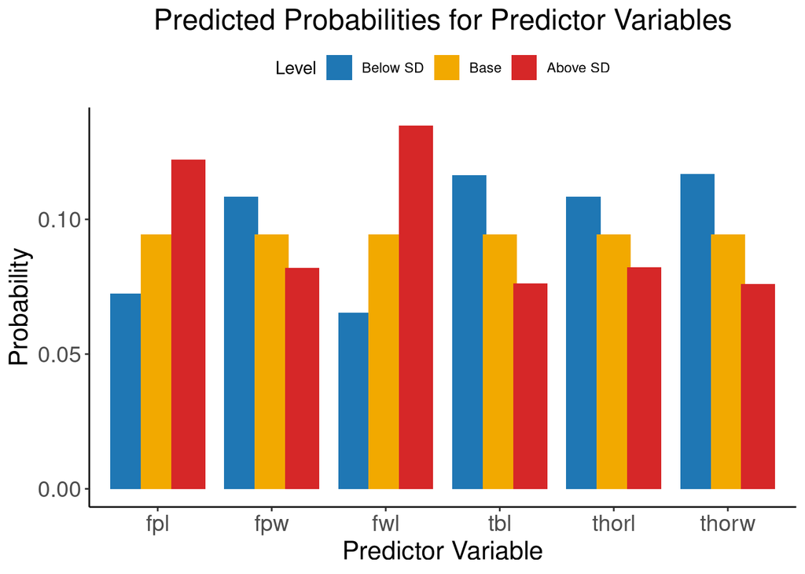

```r
# Data for plotting predicted probabilities with SD and Base
plot_data = data.frame(
  Variable = rep(c("fpw", "fpl", "thorl", "thorw", "fwl", "tbl"), each = 3),
  Level = rep(c("Below SD", "Base", "Above SD"), times = 6),
  Probability = c(
    prob_fpw_low, prob_base, prob_fpw_high,
    prob_fpl_low, prob_base, prob_fpl_high,
    prob_thorl_low, prob_base, prob_thorl_high,
    prob_thorw_low, prob_base, prob_thorw_high,
    prob_fwl_low, prob_base, prob_fwl_high,
    prob_tbl_low, prob_base, prob_tbl_high
  )
)

# Adjust the order of factor levels to make "Below SD" to the left, and "Above SD" to the right of "Base"
plot_data$Level = factor(plot_data$Level, levels = c("Below SD", "Base", "Above SD"))

# Create the plot
plot = ggplot(plot_data, aes(x = Variable, y = Probability, fill = Level)) +
  geom_bar(stat = "identity", position = position_dodge(width = 0.8)) +
  labs(
    title = "Predicted Probabilities for Predictor Variables",
    y = "Probability",
    x = "Predictor Variable"
  ) +
  scale_fill_manual(
    values = c("Below SD" = "#1f77b4", "Base" = "#f2a900", "Above SD" = "#d62728"),
    breaks = c("Below SD", "Base", "Above SD"),
    labels = c("Below SD", "Base", "Above SD")
  ) +
  theme_classic() +
  theme(
    legend.position = "top",
    plot.title = element_text(hjust = 0.5, size = 18),
    axis.text = element_text(size = 14),
    axis.title = element_text(size = 16)
  )

# Display the plot
print(plot)
```

```r
# Save the plot as a high-resolution PNG
ggsave(
  filename = "../results/predicted_probabilities_plot.png",
  plot = plot,
  width = 200,  # Width in mm
  height = 80,  # Adjusted height for document proportions
  units = "mm",
  dpi = 600
)
```

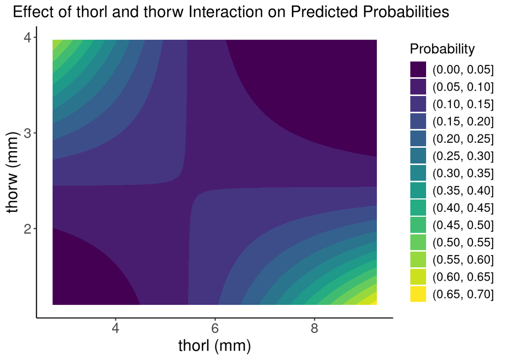

```r
# Generate grid of values for thorl and thorw
thorl_seq = seq(thorl_mean - 2 * thorl_sd, thorl_mean + 2 * thorl_sd, length.out = 50)
thorw_seq = seq(thorw_mean - 2 * thorw_sd, thorw_mean + 2 * thorw_sd, length.out = 50)

interaction_data = expand.grid(thorl = thorl_seq, thorw = thorw_seq)

# Predict probabilities
interaction_data$Probability = logit_to_prob(
  intercept +
    coef_thorl * interaction_data$thorl +
    coef_thorw * interaction_data$thorw +
    coef_thorl_thorw * interaction_data$thorl * interaction_data$thorw +
    coef_fpw * fpw_mean +
    coef_fpl * fpl_mean +
    coef_fwl * fwl_mean +
    coef_tbl * tbl_mean
)

# Create contour plot
contour_plot = ggplot(interaction_data, aes(x = thorl, y = thorw, z = Probability)) +
  geom_contour_filled() +
  labs(
    title = "Effect of thorl and thorw Interaction on Predicted Probabilities",
    x = "thorl (mm)",
    y = "thorw (mm)",
    fill = "Probability"
  ) +
  theme_classic() +
  theme(
    plot.title = element_text(hjust = 0.3, size = 16),  # Centered and adjusted title size
    axis.title = element_text(size = 16),               # Axis title size
    axis.text = element_text(size = 14),                # Axis text size
    legend.title = element_text(size = 14),             # Legend title size
    legend.text = element_text(size = 12)               # Legend text size
  )

# Display the plot
print(contour_plot)
```

```r
# Save the plot as a high-resolution PNG
ggsave(
  filename = "../results/interaction_contour_plot.png",
  plot = contour_plot,
  width = 180,  # Width in mm
  height = 120, # Adjusted height for document proportions
  units = "mm",
  dpi = 600
)
```

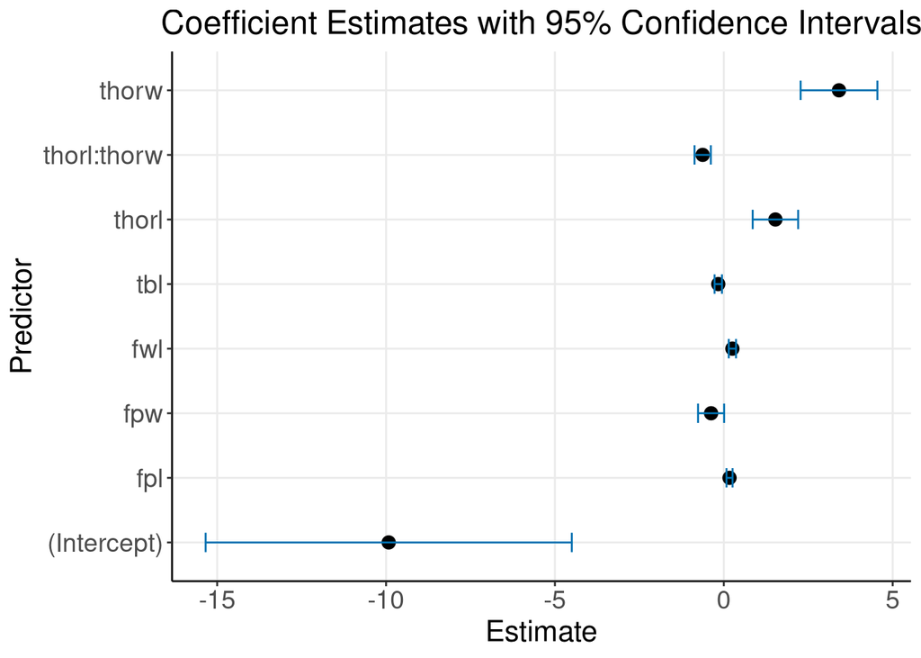

```r
# Extract coefficients and confidence intervals
coef_summary = summary(comprehensive_model)$coefficients
coef_data = data.frame(
  Term = rownames(coef_summary),
  Estimate = coef_summary[, "Estimate"],
  StdError = coef_summary[, "Std. Error"],
  LowerCI = coef_summary[, "Estimate"] - 1.96 * coef_summary[, "Std. Error"],
  UpperCI = coef_summary[, "Estimate"] + 1.96 * coef_summary[, "Std. Error"]
)

# Plot coefficients
coef_plot = ggplot(coef_data, aes(x = Term, y = Estimate)) +
  geom_point(size = 3) +
  geom_errorbar(aes(ymin = LowerCI, ymax = UpperCI), width = 0.3, color = "#0072B2") +
  labs(
    title = "Coefficient Estimates with 95% Confidence Intervals",
    y = "Estimate",
    x = "Predictor"
  ) +
  theme_classic() +
  theme(
    plot.title = element_text(hjust = 0.5, size = 18),  # Centered and scaled title
    axis.title = element_text(size = 16),               # Axis title size
    axis.text = element_text(size = 14),                # Axis text size
    panel.grid.major = element_line(size = 0.5),        # Adjust grid line thickness
    panel.grid.minor = element_blank()                  # Hide minor grid lines
  ) +
  coord_flip()  # Flip coordinates for better readability
# Display the plot
print(coef_plot)
```

```r
# Save the plot as a high-resolution PNG
ggsave(
  filename = "../results/coefficients_plot.png",
  plot = coef_plot,
  width = 200,  # Width in mm for LaTeX integration
  height = 120, # Adjusted height for readability
  units = "mm",
  dpi = 600
)
```

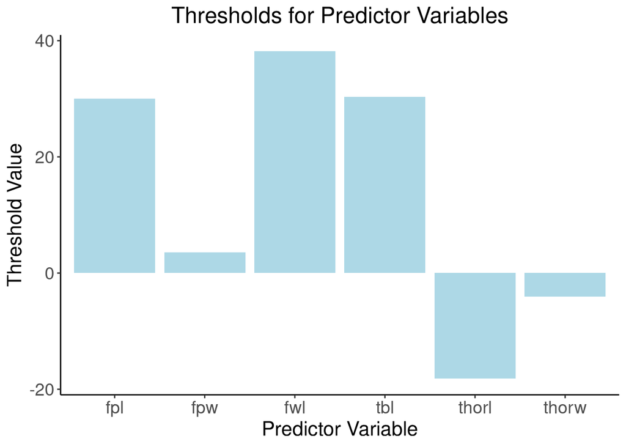

```r
# Create a dataframe for thresholds
threshold_data = data.frame(
  Variable = c("fpw", "fpl", "thorl", "thorw", "fwl", "tbl"),
  Threshold = c(fpw_threshold, fpl_threshold, thorl_threshold, thorw_threshold, fwl_threshold, tbl_threshold)
)

# Plot thresholds
threshold_plot = ggplot(threshold_data, aes(x = Variable, y = Threshold)) +
  geom_bar(stat = "identity", fill = "lightblue") +
  labs(
    title = "Thresholds for Predictor Variables",
    y = "Threshold Value",
    x = "Predictor Variable"
  ) +
  theme_classic() +
  theme(
    plot.title = element_text(hjust = 0.5, size = 18),  # Centered and scaled title
    axis.title = element_text(size = 16),               # Axis title size
    axis.text = element_text(size = 14),                # Axis text size
    panel.grid.major = element_blank(),        # Adjust grid line thickness
    panel.grid.minor = element_blank()                  # Hide minor grid lines
  )

# Display the plot
print(threshold_plot)
```

```r
# Save the plot as a high-resolution PNG
ggsave(
  filename = "../results/threshold_plot.png",
  plot = threshold_plot,
  width = 200,  # Width in mm for LaTeX integration
  height = 120, # Adjusted height for readability
  units = "mm",
  dpi = 600
)
```

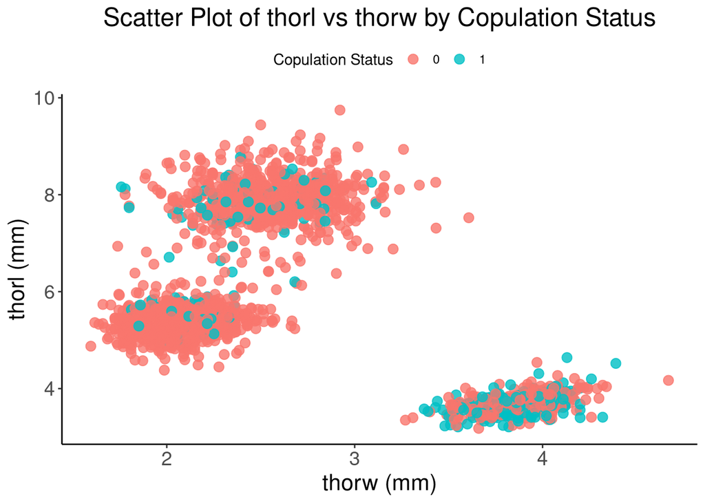

```r
# Read the data and filter accordingly
male_CS = read.csv("../data/male_CS.csv")
scatter_plot = male_CS %>%
  mutate(cop = as.factor(cop)) %>%
  ggplot(aes(x = thorw, y = thorl, colour = cop)) +
  geom_point(size = 3, alpha = 0.8) +  # Adjusted point size and transparency
  theme_classic() +
  labs(
    title = "Scatter Plot of thorl vs thorw by Copulation Status",
    x = "thorw (mm)",  # Added unit for clarity
    y = "thorl (mm)",  # Added unit for clarity
    colour = "Copulation Status"
  ) +
  theme(
    legend.position = "top",  # Position legend at the top
    plot.title = element_text(hjust = 0.5, size = 18),  # Centered and scaled title
    axis.title = element_text(size = 16),              # Adjusted axis title size
    axis.text = element_text(size = 14)                # Adjusted axis text size
  )

# Display the plot
print(scatter_plot)
```

```r
# Save the plot as a high-resolution PNG
ggsave(
  filename = "../results/thorl_vs_thorw_scatter.png",
  plot = scatter_plot,
  width = 200,  # Width in mm for LaTeX integration
  height = 150, # Adjusted height for readability
  units = "mm",
  dpi = 600
)
```